# ВКР. Сахарова П.А., КББО-01-20

## Описание данных

За основу был взят набор данных с источника Kaggle “Supermarket store branches sales analysis”.  
Таблица содержит следующие колонки:  
* Store.ID (идентификатор магазина);  
* Store_Area (площадь магазина в квадратных ярдах, числовая переменная);  
* Items_Available (число доступных различных товаров, числовая переменная);  
* Daily_Customer_Count (среднее число посетителей в день, числовая переменная);  
* Store_Sales (продажи магазина в долларах США, числовая переменная).

## 1. Чтение данных. Добавление переменных

Сохраним датасет в переменную df и посмотрим на первые 5 строк.

|  | Store.ID | Store_Area | Items_Available | Daily_Customer_Count | Store_Sales |
| --- | --- | --- | --- | --- | --- |
| 1 | 1 | 1659 | 1961 | 530 | 66490 |
| 2 | 2 | 1461 | 1752 | 210 | 39820 |
| 3 | 3 | 1340 | 1609 | 720 | 54010 |
| 4 | 4 | 1451 | 1748 | 620 | 53730 |
| 5 | 5 | 1770 | 2111 | 450 | 46620 |

Не хватает категориальных переменных. Создадим их сами.  
Пусть Self_Service - бинарная переменная, которая разбивает супермаркеты на два класса: те, в которых есть кассы самообслуживания (Yes) и те, в которых их нет (No).  
Пусть Organisation_Level - категориальная переменная, классифицирующая супермаркеты по уровню организации: International (располагаются в разных странах), Federal (располагаются в разных субъектах одной страны), Regional (располагаются в разных регионах одного субъекта одной страны), Local (располагаются в пределах одного города).

|  | Store.ID | Store_Area | Items_Available | Daily_Customer_Count | Store_Sales | Self_Service | Organisation_Level |
| --- | --- | --- | --- | --- | --- | --- | --- |
| 1 | 1 | 1659 | 1961 | 530 | 66490 | No | Regional |
| 2 | 2 | 1461 | 1752 | 210 | 39820 | Yes | Federal |
| 3 | 3 | 1340 | 1609 | 720 | 54010 | Yes | Regional |
| 4 | 4 | 1451 | 1748 | 620 | 53730 | No | Local |
| 5 | 5 | 1770 | 2111 | 450 | 46620 | Yes | Regional |
| 6 | 6 | 1442 | 1733 | 760 | 45260 | No | Local |
| 7 | 7 | 1542 | 1858 | 1030 | 72240 | Yes | Federal |
| 8 | 8 | 1261 | 1507 | 1020 | 37720 | No | Federal |
| 9 | 9 | 1090 | 1321 | 680 | 46310 | No | Federal |
| 10 | 10 | 1030 | 1235 | 1130 | 44150 | No | Regional |

Добавим пропуски в любые 25 строк по переменной Store_Area и в любые 10 строк по переменной Daily_Customer_Count. Выведем наблюдения, в которых содержатся пропущенные значения.

|  | Store.ID | Store_Area | Items_Available | Daily_Customer_Count | Store_Sales | Self_Service | Organisation_Level |
| --- | --- | --- | --- | --- | --- | --- | --- |
| 8 | 8 | NA | 1507 | 1020 | 37720 | No | Federal |
| 21 | 21 | NA | 1700 | 370 | 43460 | Yes | International |
| 50 | 50 | NA | 1688 | 1040 | 76350 | Yes | International |
| 60 | 60 | NA | 2070 | 460 | 53870 | Yes | International |
| 191 | 191 | 1391 | 1649 | NA | 83750 | No | International |
| 257 | 257 | NA | 2003 | 910 | 82930 | Yes | Local |
| 285 | 285 | NA | 2216 | 1020 | 64820 | Yes | Local |
| 288 | 288 | NA | 1799 | 510 | 38970 | Yes | Regional |
| 293 | 293 | NA | 1622 | 560 | 44860 | Yes | Local |
| 303 | 303 | NA | 1648 | 720 | 77070 | Yes | Regional |

[output cut: 25 more lines]

Требования задания соблюдены. Приступаем к EDA-анализу.

## 1. EDA-анализ

### 1.1 Структура данных. Преобразование категорий в факторы

Выведем общую информацию о наших данных.

```
##     Store.ID       Store_Area   Items_Available Daily_Customer_Count
##  Min.   :  1.0   Min.   : 775   Min.   : 932    Min.   :  10.0
##  1st Qu.:224.8   1st Qu.:1312   1st Qu.:1576    1st Qu.: 600.0
##  Median :448.5   Median :1476   Median :1774    Median : 780.0
##  Mean   :448.5   Mean   :1485   Mean   :1782    Mean   : 785.8
##  3rd Qu.:672.2   3rd Qu.:1655   3rd Qu.:1983    3rd Qu.: 967.5
##  Max.   :896.0   Max.   :2229   Max.   :2667    Max.   :1560.0
##                  NA's   :25                     NA's   :10
##   Store_Sales     Self_Service       Organisation_Level
##  Min.   : 14920   Length:896         Length:896
##  1st Qu.: 46530   Class :character   Class :character
##  Median : 58605   Mode  :character   Mode  :character
##  Mean   : 59351
##  3rd Qu.: 71873
##  Max.   :116320
##
```

Как видим, в таблице приведены данные по 896 магазинам. Все колонки, за исключением двух последних, имеют целочисленный тип. Для корректной работы статистических тестов сделаем категориальные переменные факторными.

```
## 'data.frame':    896 obs. of  7 variables:
##  $ Store.ID            : int  1 2 3 4 5 6 7 8 9 10 ...
##  $ Store_Area          : int  1659 1461 1340 1451 1770 1442 1542 NA 1090 1030 ...
##  $ Items_Available     : int  1961 1752 1609 1748 2111 1733 1858 1507 1321 1235 ...
##  $ Daily_Customer_Count: int  530 210 720 620 450 760 1030 1020 680 1130 ...
##  $ Store_Sales         : int  66490 39820 54010 53730 46620 45260 72240 37720 46310 44150 ...
##  $ Self_Service        : Factor w/ 2 levels "No","Yes": 1 2 2 1 2 1 2 1 1 1 ...
##  $ Organisation_Level  : Factor w/ 4 levels "Federal","International",..: 4 1 4 3 4 3 1 1 1 4 ...
```

### 1.2 Поиск выбросов и обработка пропущенных значений

Из таблицы выше (summary(df)) следует, что разброс значений по переменной Store_Area не очень велик: площадь магазина лежит в пределах от 775 до 2229 кв. ярдов. Посмотрим на распределение значений площади.

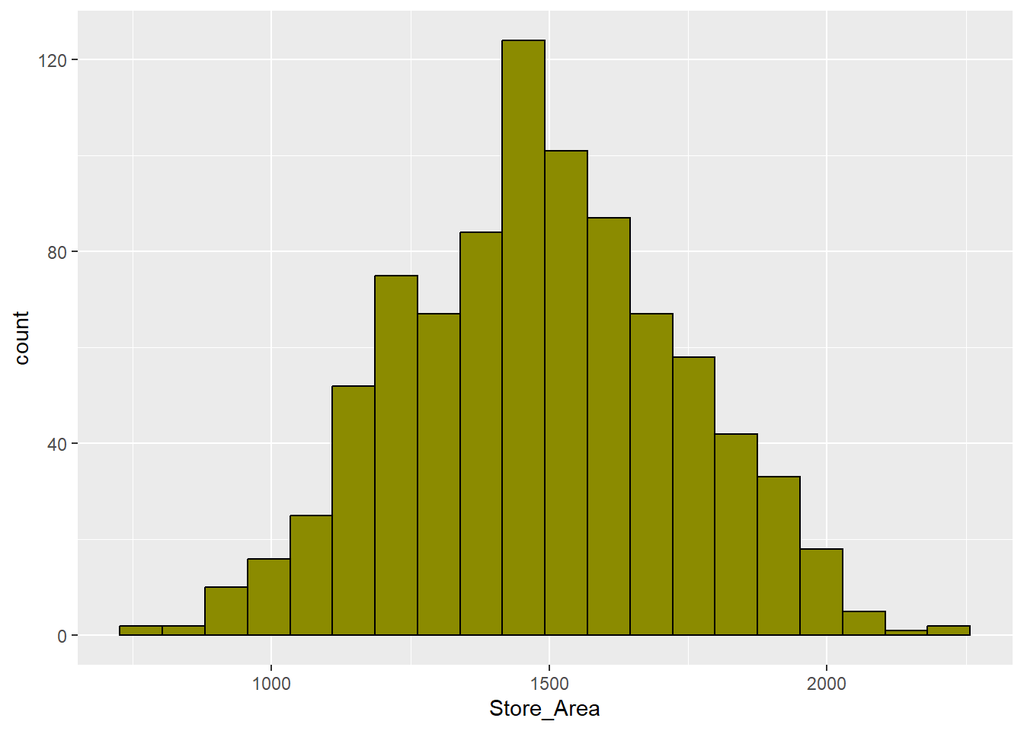

Распределение напоминает нормальное. Проверим формально критерием Шапиро-Уилка.

```
##
##  Shapiro-Wilk normality test
##
## data:  df$Store_Area
## W = 0.99705, p-value = 0.1118
```

p-value > 0.05, то есть оснований отвергнуть нулевую гипотезу о соответствии распределения нормальному у нас нет.  
Судя по гистограмме, выбросов нет или их немного. Убедимся в этом, построив боксплот.

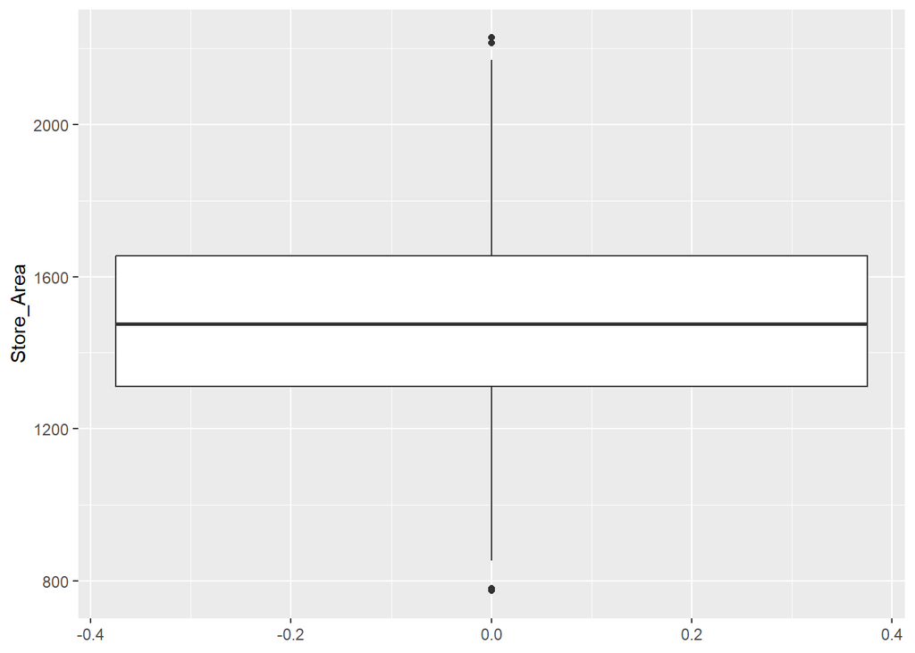

Всё же они есть. Посмотрим на эти строки.

|  | Store.ID | Store_Area | Items_Available | Daily_Customer_Count | Store_Sales | Self_Service | Organisation_Level |
| --- | --- | --- | --- | --- | --- | --- | --- |
| 159 | 159 | 775 | 932 | 1090 | 42530 | No | Federal |
| 467 | 467 | 2229 | 2667 | 660 | 87410 | Yes | Federal |
| 541 | 541 | 2214 | 2647 | 740 | 65900 | Yes | Federal |
| 866 | 866 | 780 | 951 | 790 | 25600 | Yes | Regional |

Нельзя сказать, что значения сильно выбиваются из общего ряда (другое дело - встретить площадь 1 кв. ярд или, наоборот, 100 000 кв. ярдов), поэтому оставим их.  
Мы приняли решение, что выбросов нет. Следовательно, характеристикой столбца вполне послужит среднее значение. Пропущенные значения переменной Store_Area заменим средним значением этого столбца (рассчитанным без учета пропусков).

```
##     Store.ID       Store_Area   Items_Available Daily_Customer_Count
##  Min.   :  1.0   Min.   : 775   Min.   : 932    Min.   :  10.0
##  1st Qu.:224.8   1st Qu.:1318   1st Qu.:1576    1st Qu.: 600.0
##  Median :448.5   Median :1485   Median :1774    Median : 780.0
##  Mean   :448.5   Mean   :1485   Mean   :1782    Mean   : 785.8
##  3rd Qu.:672.2   3rd Qu.:1648   3rd Qu.:1983    3rd Qu.: 967.5
##  Max.   :896.0   Max.   :2229   Max.   :2667    Max.   :1560.0
##                                                 NA's   :10
##   Store_Sales     Self_Service     Organisation_Level
##  Min.   : 14920   No :461      Federal      :222
##  1st Qu.: 46530   Yes:435      International:214
##  Median : 58605                Local        :237
##  Mean   : 59351                Regional     :223
##  3rd Qu.: 71873
##  Max.   :116320
##
```

Пропусков по переменной Store_Area больше нет. Посмотрим на распределение переменной Daily_Customer_Count.

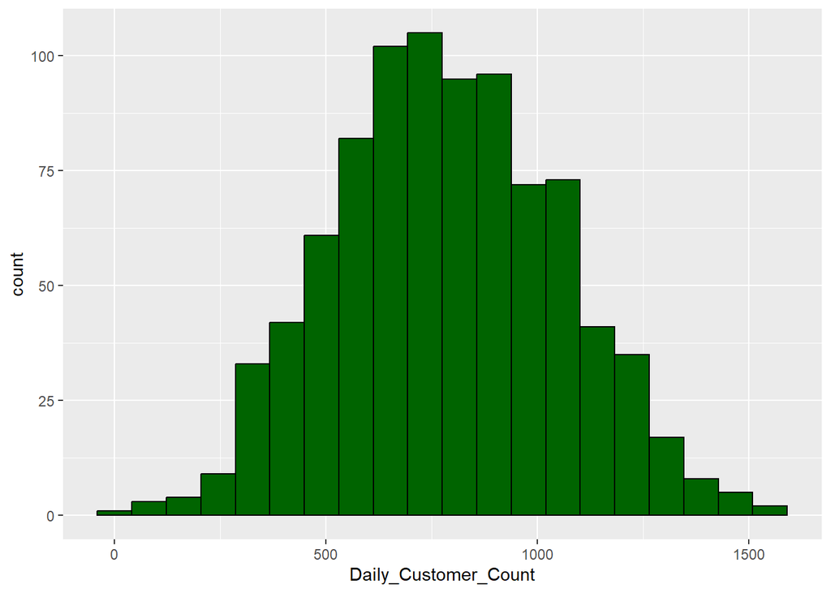

Распределение также напоминает нормальное.

```
##
##  Shapiro-Wilk normality test
##
## data:  df$Daily_Customer_Count
## W = 0.99788, p-value = 0.3283
```

Поищем выбросы.

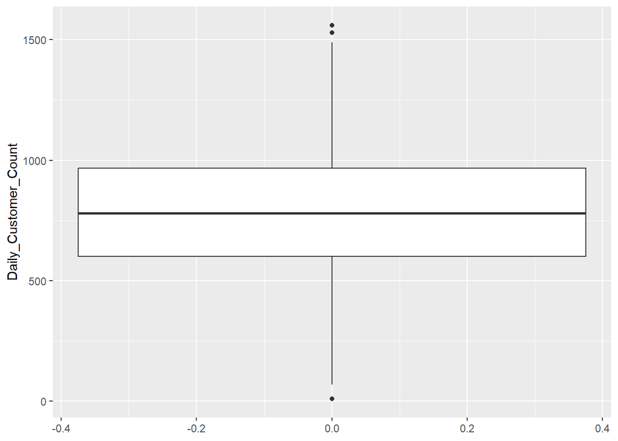

Выбросов немного, и значения, на мой взгляд, не противоречат смыслу.  
В этот раз с пропущенными значениями поступим иначе: просто удалим строки (их всего 10, по сравнению с размером датасета - очень маленькое число).  
Заодно удалим столбец Store.ID - для анализа он бесполезен.

```
##    Store_Area   Items_Available Daily_Customer_Count  Store_Sales
##  Min.   : 775   Min.   : 932    Min.   :  10.0       Min.   : 14920
##  1st Qu.:1316   1st Qu.:1571    1st Qu.: 600.0       1st Qu.: 46250
##  Median :1485   Median :1772    Median : 780.0       Median : 58570
##  Mean   :1484   Mean   :1781    Mean   : 785.8       Mean   : 59288
##  3rd Qu.:1649   3rd Qu.:1986    3rd Qu.: 967.5       3rd Qu.: 71818
##  Max.   :2229   Max.   :2667    Max.   :1560.0       Max.   :116320
##  Self_Service     Organisation_Level
##  No :457      Federal      :220
##  Yes:429      International:210
##               Local        :234
##               Regional     :222
##
##
```

Пропущенных значений больше нет.

Посмотрим на распределение переменной Items_Available.

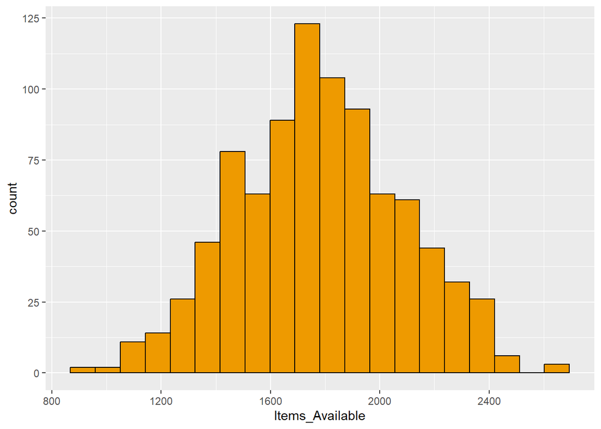

```
##
##  Shapiro-Wilk normality test
##
## data:  df$Items_Available
## W = 0.99715, p-value = 0.1195
```

## 2. Визуализация и поиск зависимостей

Посмотрим, насколько отличается распределение продаж в зависимости от типа организации супермаркета.

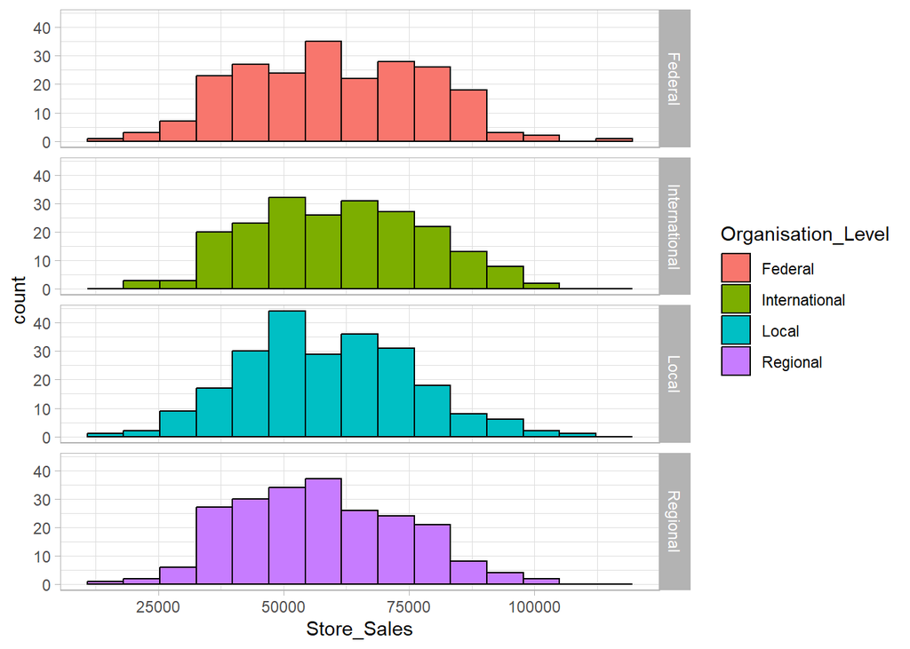

Похоже, распределение продаж не зависит от уровня организации магазина (следует помнить, что категории были присвоены случайным образом). Посмотрим, влияет ли наличие касс самообслуживания на количество посетителей магазина.

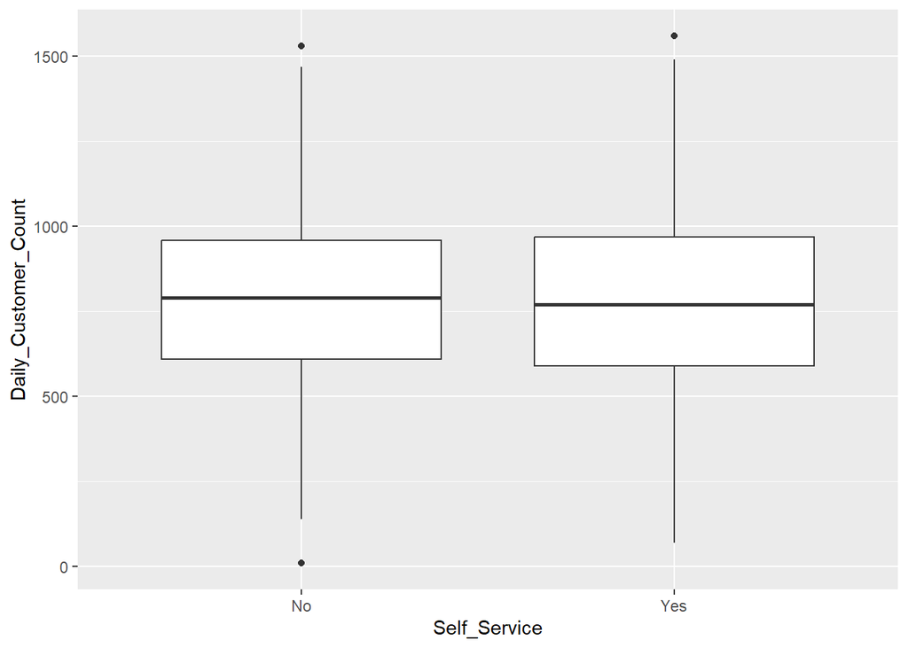

Разницы почти нет.  
Посмотрим на распределение переменной “Продажи”.

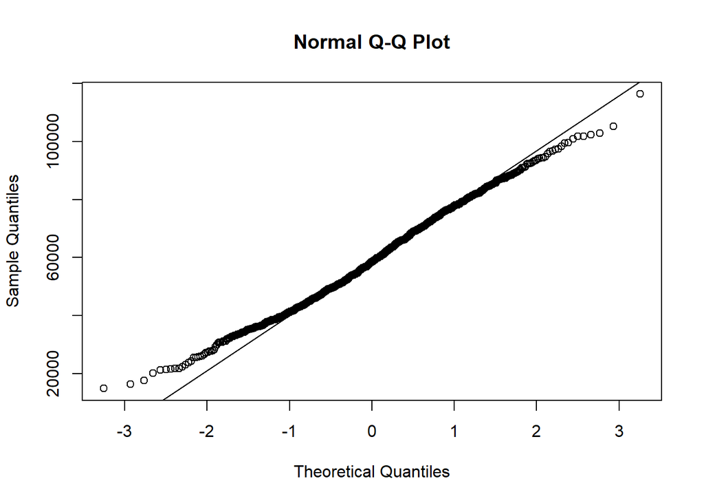

```
##
##  Shapiro-Wilk normality test
##
## data:  df$Store_Sales
## W = 0.99372, p-value = 0.0009053
```

```
##
##  Asymptotic one-sample Kolmogorov-Smirnov test
##
## data:  df$Store_Sales
## D = 1, p-value < 2.2e-16
## alternative hypothesis: two-sided
```

Предположение оказалось неверным. Распределение Store_Sales отличается от нормального. Попробуем прологарифмировать переменную, чтобы “подправить” распределение.

```
##
##  Shapiro-Wilk normality test
##
## data:  log(df$Store_Sales)
## W = 0.97331, p-value = 1.153e-11
```

Не помогло. Попробуем извлечь корень из исходных данных.

```
##
##  Shapiro-Wilk normality test
##
## data:  sqrt(df$Store_Sales)
## W = 0.99373, p-value = 0.0009167
```

Исправить распределение не удалось.

Попробуем поискать зависимость между переменными.

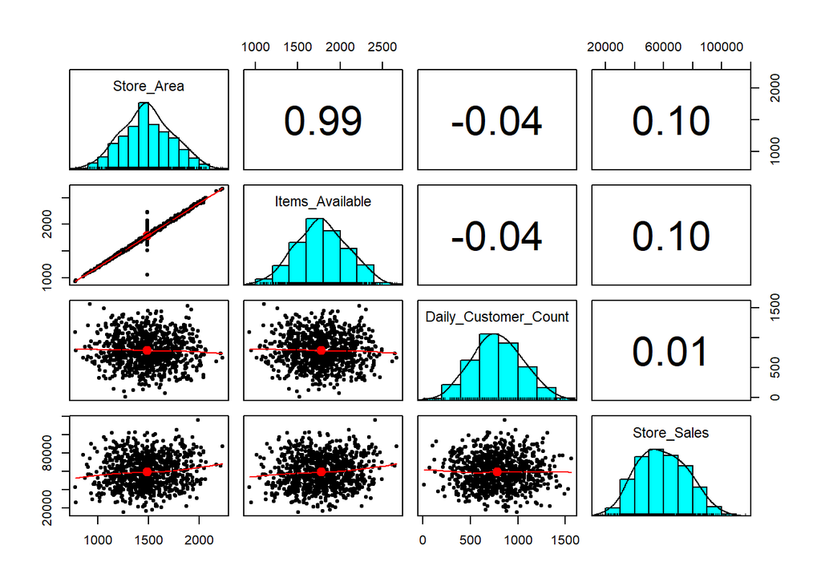

Линейно связаны между собой только ассортимент магазина и его площадь, что довольно логично.

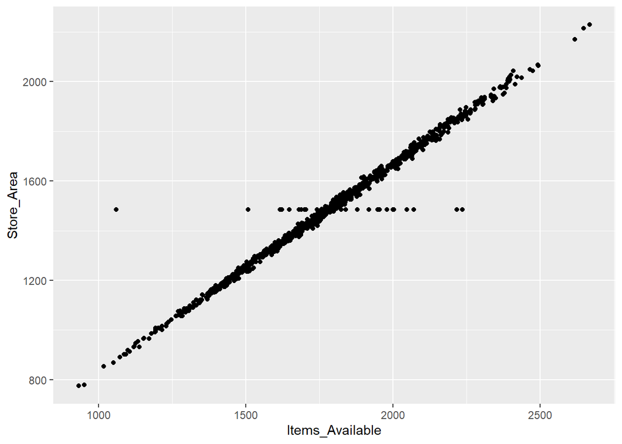

Сложно выявить какой-то тренд относительно переменной Store_Sales.

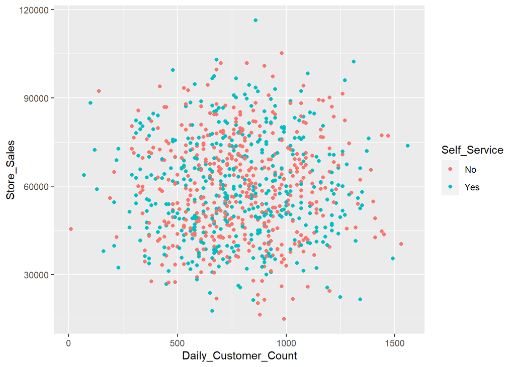

Наличие касс самообслуживания тоже не оказало влияния на продажи и число посетителей.  
Посмотрим ещё раз на коэффициенты корреляции между переменными.

```
##                       Store_Area Items_Available Daily_Customer_Count
## Store_Area            1.00000000      0.98969781         -0.043566826
## Items_Available       0.98969781      1.00000000         -0.041178772
## Daily_Customer_Count -0.04356683     -0.04117877          1.000000000
## Store_Sales           0.09558138      0.09859199          0.007241916
##                      Store_Sales
## Store_Area           0.095581381
## Items_Available      0.098591993
## Daily_Customer_Count 0.007241916
## Store_Sales          1.000000000
```

Сильная корреляция присутствует только между переменными Store_Area и Items_Available. Проверим значимость коэффициентов.

```
##                       Store_Area Items_Available Daily_Customer_Count
## Store_Area           0.000000000     0.000000000            0.5853568
## Items_Available      0.000000000     0.000000000            0.5853568
## Daily_Customer_Count 0.195118923     0.220761356            0.0000000
## Store_Sales          0.004405622     0.003306764            0.8295649
##                      Store_Sales
## Store_Area            0.01762249
## Items_Available       0.01653382
## Daily_Customer_Count  0.82956494
## Store_Sales           0.00000000
```

Значимыми оказались только коэффициенты между Store_Area и Items_Available, Store_Area и Store_Sales, Items_Available и Store_Sales.

Сначала я собиралась исследовать зависимость выручки супермаркетов от посещаемости, ассортимента и площади магазина. Однако, поскольку линейной взаимосвязи между ними не наблюдается, лучше посмотреть, какие факторы влияют на площадь магазина.

## 3. Модели линейной регрессии

### 3.1 Разбивка датасета. Полная и оптимальная модели

Сначала отберём данные для прогнозирования: последние 20 строк датасета уберём из обучающей выборки и оставим их для контрольной проверки.

Сперва построим полную модель, включив в неё все факторы.

```
##
## Call:
## lm(formula = Store_Area ~ ., data = df_train)
##
## Residuals:
##     Min      1Q  Median      3Q     Max
## -365.08   -8.35   -0.24   10.09  590.19
##
## Coefficients:
##                                   Estimate Std. Error t value Pr(>|t|)
## (Intercept)                     35.0888959  9.4734112   3.704 0.000226 ***
## Items_Available                  0.8180167  0.0040986 199.584  < 2e-16 ***
## Daily_Customer_Count            -0.0030207  0.0046536  -0.649 0.516441
## Store_Sales                     -0.0000264  0.0000720  -0.367 0.713915
## Self_ServiceYes                 -2.4478743  2.4593901  -0.995 0.319862
## Organisation_LevelInternational -6.4936374  3.5342620  -1.837 0.066506 .
## Organisation_LevelLocal         -3.5647022  3.4388239  -1.037 0.300212
## Organisation_LevelRegional      -3.0679463  3.4581710  -0.887 0.375242
## ---
## Signif. codes:  0 '***' 0.001 '**' 0.01 '*' 0.05 '.' 0.1 ' ' 1
##
## Residual standard error: 36.09 on 858 degrees of freedom
## Multiple R-squared:  0.9793, Adjusted R-squared:  0.9791
## F-statistic:  5790 on 7 and 858 DF,  p-value: < 2.2e-16
```

Значение p-value говорит о значимости только числа товаров, что было понятно ещё на этапе корреляционного анализа. О низкой значимости Daily_Customer_Count и Store_Sales свидетельствуют самые высокие значения p-value и низкие значения коэффициентов. В данном случае площадь полностью описывается количеством разных товаров в ассортименте супермаркета.

```
##
## Call:
## lm(formula = Store_Area ~ Items_Available, data = df_train)
##
## Residuals:
##     Min      1Q  Median      3Q     Max
## -371.38   -7.91   -0.31    9.56  591.58
##
## Coefficients:
##                  Estimate Std. Error t value Pr(>|t|)
## (Intercept)     26.510332   7.346001   3.609 0.000325 ***
## Items_Available  0.818144   0.004061 201.442  < 2e-16 ***
## ---
## Signif. codes:  0 '***' 0.001 '**' 0.01 '*' 0.05 '.' 0.1 ' ' 1
##
## Residual standard error: 36.07 on 864 degrees of freedom
## Multiple R-squared:  0.9792, Adjusted R-squared:  0.9791
## F-statistic: 4.058e+04 on 1 and 864 DF,  p-value: < 2.2e-16
```

Константа и Items_Available значимы.  
Значение Adjusted R-squared совпадает в обеих моделях, что позволяет говорить о их взаимозаменяемости. Убедимся в этом с помощью дисперсионного анализа.

|  | Res.Df | RSS | Df | Sum of Sq | F | Pr(>F) |
| --- | --- | --- | --- | --- | --- | --- |
| 1 | 858 | 1117772 | NA | NA | NA | NA |
| 2 | 864 | 1124043 | -6 | -6271.043 | 0.8022739 | 0.5682246 |

Значение p-value превышает 0.05, поэтому мы не отклоняем нулевую гипотезу о том, что модель с одним признаком работает не хуже полной модели. Покажем это с помощью пошагового исключения предикторов из полной модели.

```
## Start:  AIC=6219.13
## Store_Area ~ Items_Available + Daily_Customer_Count + Store_Sales +
##     Self_Service + Organisation_Level
##
##                        Df Sum of Sq      RSS    AIC
## - Organisation_Level    3      4432  1122203 6216.6
## - Store_Sales           1       175  1117947 6217.3
## - Daily_Customer_Count  1       549  1118321 6217.6
## - Self_Service          1      1291  1119062 6218.1
## <none>                               1117772 6219.1
## - Items_Available       1  51893847 53011619 9559.2
##
## Step:  AIC=6216.55
## Store_Area ~ Items_Available + Daily_Customer_Count + Store_Sales +
##     Self_Service
##
##                        Df Sum of Sq      RSS    AIC
## - Store_Sales           1       195  1122398 6214.7
## - Daily_Customer_Count  1       388  1122591 6214.9
## - Self_Service          1      1276  1123480 6215.5
## <none>                               1122203 6216.6
## - Items_Available       1  51993244 53115448 9554.9
##
## Step:  AIC=6214.7
## Store_Area ~ Items_Available + Daily_Customer_Count + Self_Service
##
##                        Df Sum of Sq      RSS    AIC
## - Daily_Customer_Count  1       397  1122796 6213.0
## - Self_Service          1      1276  1123675 6213.7
## <none>                               1122398 6214.7
## - Items_Available       1  52615699 53738098 9563.0
##
## Step:  AIC=6213.01
## Store_Area ~ Items_Available + Self_Service
##
##                   Df Sum of Sq      RSS    AIC
## - Self_Service     1      1247  1124043 6212.0
## <none>                          1122796 6213.0
## - Items_Available  1  52727679 53850474 9562.8
##
## Step:  AIC=6211.97
## Store_Area ~ Items_Available
##
##                   Df Sum of Sq      RSS    AIC
## <none>                          1124043 6212.0
## - Items_Available  1  52792235 53916278 9561.8
```

```
##
## Call:
## lm(formula = Store_Area ~ Items_Available, data = df_train)
##
## Residuals:
##     Min      1Q  Median      3Q     Max
## -371.38   -7.91   -0.31    9.56  591.58
##
## Coefficients:
##                  Estimate Std. Error t value Pr(>|t|)
## (Intercept)     26.510332   7.346001   3.609 0.000325 ***
## Items_Available  0.818144   0.004061 201.442  < 2e-16 ***
## ---
## Signif. codes:  0 '***' 0.001 '**' 0.01 '*' 0.05 '.' 0.1 ' ' 1
##
## Residual standard error: 36.07 on 864 degrees of freedom
## Multiple R-squared:  0.9792, Adjusted R-squared:  0.9791
## F-statistic: 4.058e+04 on 1 and 864 DF,  p-value: < 2.2e-16
```

Как видим, алгоритм пошагового исключения также оставил только один фактор. Критерий Акаике принимает наименьшее значение в этом случае, что свидетельствует об оптимальности последней модели.

### 3.2 Предсказание значений Store_Area

Попробуем предсказать значения колонки “Площадь” в df_predict с помощью второй модели.

|  | Store_Area | Items_Available | Daily_Customer_Count | Store_Sales | Self_Service | Organisation_Level | Predicted_Store_Area | Difference |
| --- | --- | --- | --- | --- | --- | --- | --- | --- |
| 867 | 1691 | 2023 | 540 | 60270 | Yes | International | 1681.615 | 9.38506812 |
| 868 | 1259 | 1493 | 100 | 88270 | Yes | International | 1247.999 | 11.00120150 |
| 869 | 1771 | 2138 | 820 | 57820 | No | Local | 1775.701 | -4.70145138 |
| 870 | 1205 | 1468 | 1210 | 61210 | Yes | Federal | 1227.545 | -22.54520730 |
| 871 | 1792 | 2131 | 810 | 76420 | No | Regional | 1769.974 | 22.02555415 |
| 872 | 1263 | 1516 | 780 | 70980 | No | Local | 1266.816 | -3.81610240 |
| 873 | 1344 | 1605 | 1160 | 76740 | No | Local | 1339.631 | 4.36911294 |
| 874 | 1819 | 2187 | 590 | 47920 | No | International | 1815.790 | 3.20950987 |
| 875 | 1357 | 1625 | 1140 | 52160 | No | Federal | 1355.994 | 1.00623998 |
| 876 | 1396 | 1673 | 690 | 32740 | Yes | Local | 1395.265 | 0.73534488 |

[output cut: 10 more lines]

Рассчитаем среднеквадратичную ошибку (RMSE) для второй модели.

```
## [1] 48.72883
```

Сравним с ошибкой полной модели.

```
## [1] 50.76198
```

Ошибка модели, учитывающей все факторы, выше, чем у модели с одним фактором.

### 3.3 Визуальная диагностика моделей

Построим диагностические диаграммы двух моделей.

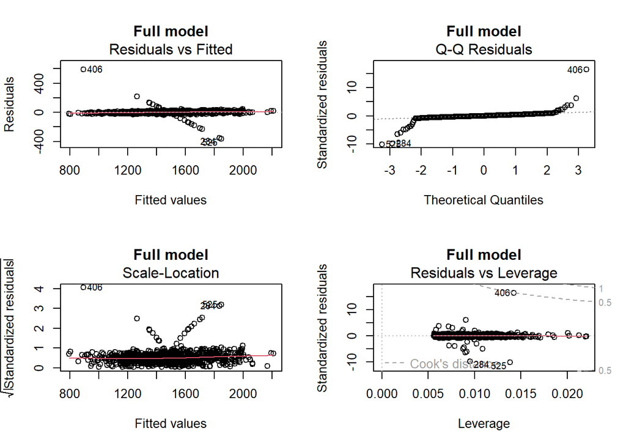

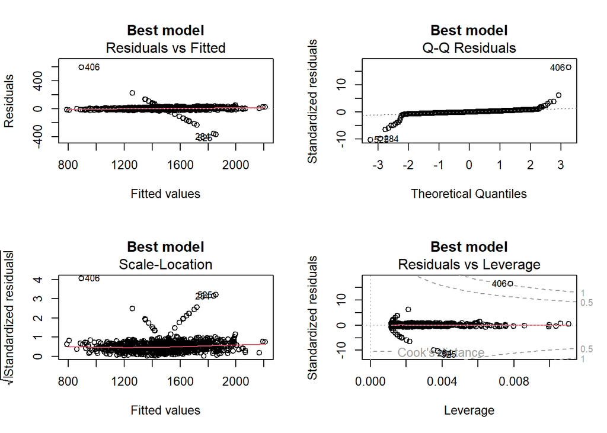

### 3.4 Статистическая диагностика моделей (проверка соблюдения предпосылок)

1. Мультиколлинеарность  
   Искать зависимости между предикторами придется только в полной модели.

```
##                          GVIF Df GVIF^(1/(2*Df))
## Items_Available      1.016996  1        1.008462
## Daily_Customer_Count 1.007003  1        1.003495
## Store_Sales          1.017731  1        1.008827
## Self_Service         1.004415  1        1.002205
## Organisation_Level   1.014324  3        1.002373
```

Все значения VIF едва превышают 1, что говорит об отсутствии корреляции между признаками. Значит, модель не является избыточной с точки зрения повторения скоррелированных признаков.

2. Линейность моделей  
   Проверим с помощью теста Рамсея, все ли степени присутствуют в моделях.

```
##
##  RESET test
##
## data:  model_1
## RESET = 1.0335, df1 = 2, df2 = 856, p-value = 0.3562
```

```
##
##  RESET test
##
## data:  model_2
## RESET = 0.95381, df1 = 2, df2 = 862, p-value = 0.3857
```

p-value в обоих случаях превышает 0.05, значит, нулевую гипотезу (“Модель построена корректно, вводить другие степени не требуется”) отклонить нет оснований, и наши модели линейны.

3. Проверка на гетероскедастичность  
   Проверим двумя тестами:
- нулевая гипотеза теста Бройша-Пагана: гетероскедастичность отсутствует;
- нулевая гипотеза теста Голдфелда-Квандта: гетероскедастичность отсутствует.

```
##
##  studentized Breusch-Pagan test
##
## data:  model_1
## BP = 8.7303, df = 7, p-value = 0.2726
```

```
##
##  Goldfeld-Quandt test
##
## data:  model_1
## GQ = 0.45559, df1 = 425, df2 = 425, p-value = 1
## alternative hypothesis: variance increases from segment 1 to 2
```

```
##
##  studentized Breusch-Pagan test
##
## data:  model_2
## BP = 0.55021, df = 1, p-value = 0.4582
```

```
##
##  Goldfeld-Quandt test
##
## data:  model_2
## GQ = 0.45692, df1 = 431, df2 = 431, p-value = 1
## alternative hypothesis: variance increases from segment 1 to 2
```

p-value превышает 0.05, оснований для отвергания нулевой гипотезы нет. Следовательно, разброс остатков обеих моделей одинаков.

4. Влиятельные наблюдения  
   Используем метрику расстояний Кука для поиска выбросов. Выведем максимальное значение метрики для второй модели.

```
##      406
## 1.066717
```

Наблюдение 406 похоже на выброс. Можно по-разному выбирать порог для идентификации выбросов.  
Наблюдение оказывает большое влияние на предсказания модели, если:  
1) расстояние Кука больше 1 или  
2) расстояние Кука больше 4/(N-k-1), где N - количество наблюдений в обучающей выборке, k - количество предикторов.  
Будем использовать второй подход для определения порога.

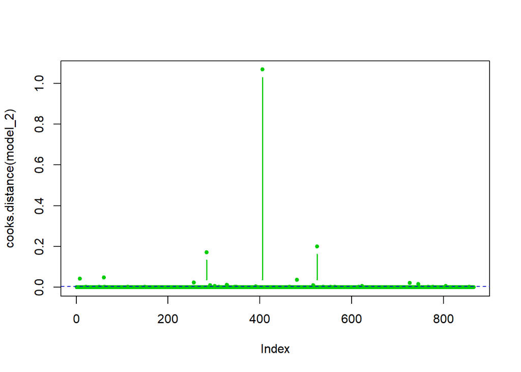

Видим, что у нас довольно много выбросов.

```
##           8          60         256         284         292         302
## 0.041503370 0.047049130 0.022257256 0.172099068 0.009817044 0.006431992
##         328         329         406         481         516         525
## 0.011623265 0.010644414 1.066716504 0.036512002 0.010745285 0.200403056
##         623         727         745         805
## 0.005333579 0.021189478 0.016414897 0.006599130
```

16 сомнительных наблюдений. Посмотрим, что будет, если исключить их из набора данных.

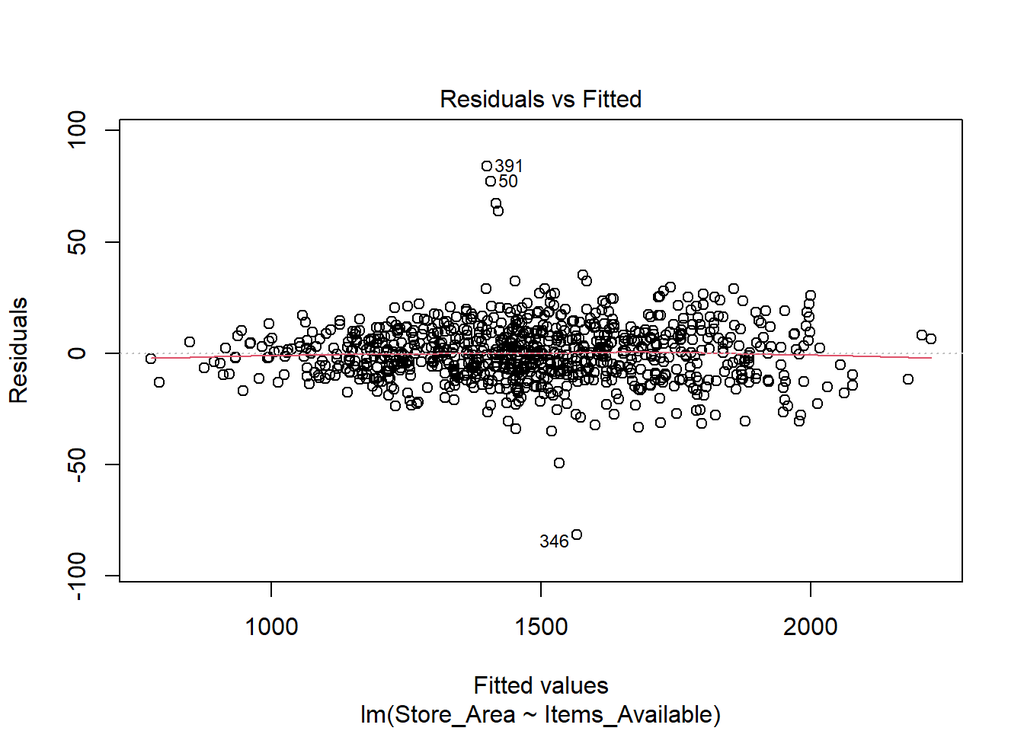

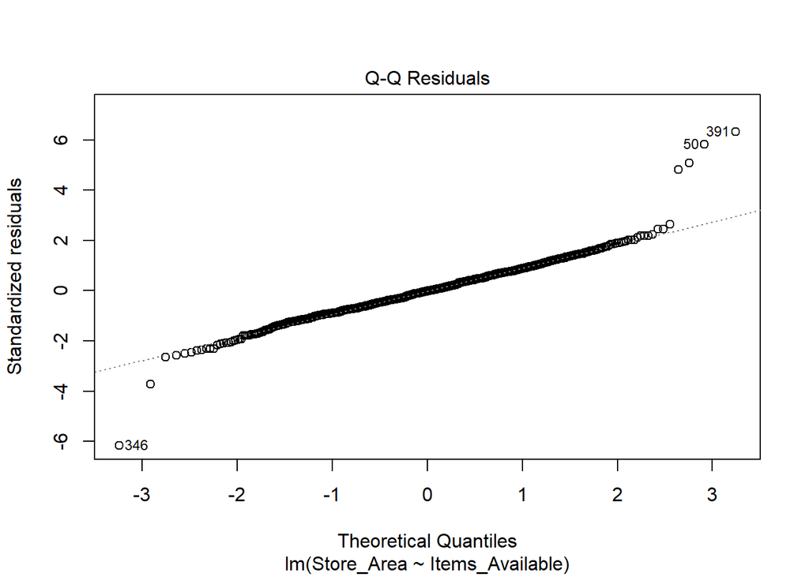

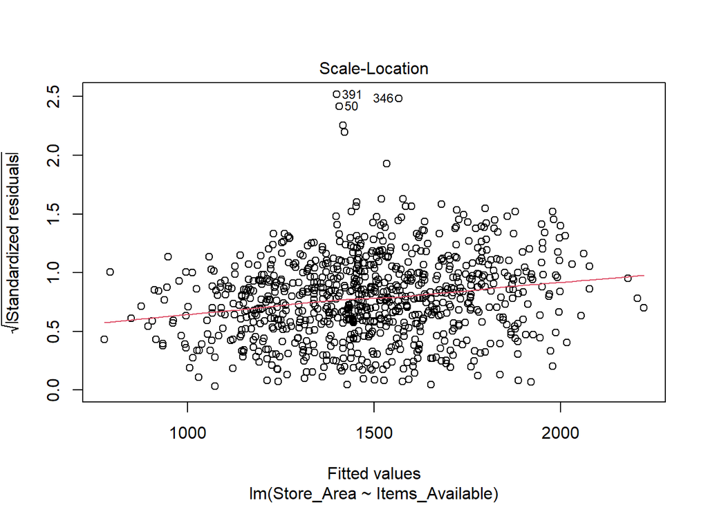

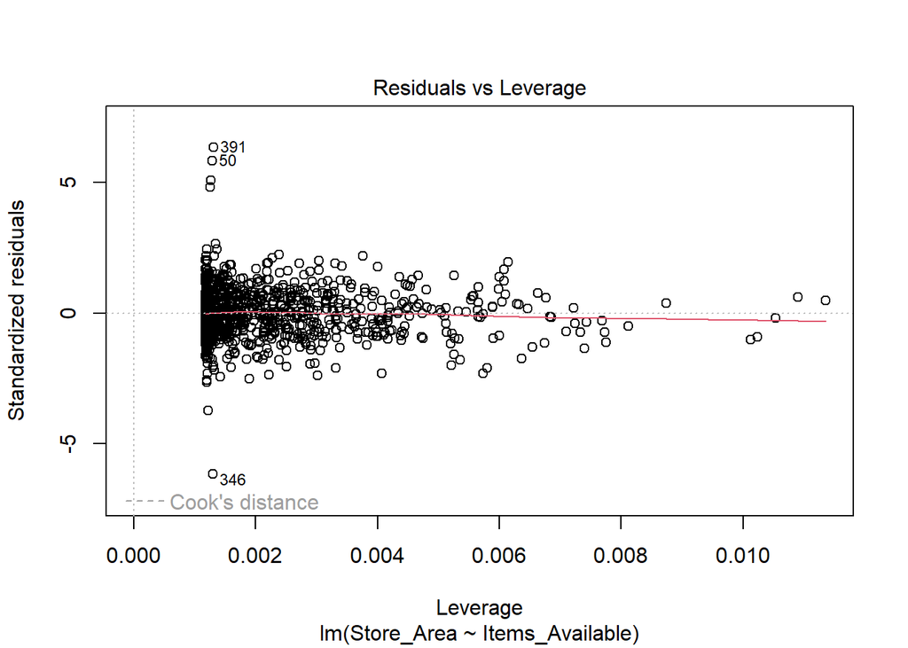

```
##
## Call:
## lm(formula = Store_Area ~ Items_Available, data = df_train[-bad_vector,
##     ])
##
## Residuals:
##     Min      1Q  Median      3Q     Max
## -81.736  -8.408  -0.097   8.012  84.014
##
## Coefficients:
##                 Estimate Std. Error t value Pr(>|t|)
## (Intercept)     1.188538   2.729145   0.435    0.663
## Items_Available 0.832916   0.001511 551.374   <2e-16 ***
## ---
## Signif. codes:  0 '***' 0.001 '**' 0.01 '*' 0.05 '.' 0.1 ' ' 1
##
## Residual standard error: 13.26 on 848 degrees of freedom
## Multiple R-squared:  0.9972, Adjusted R-squared:  0.9972
## F-statistic: 3.04e+05 on 1 and 848 DF,  p-value: < 2.2e-16
```

В результате исключения строк, содержащих выбросы, мы добились отсутствия наблюдений за пунктирными границами, которые влияют на модель, и даже немного повысили Adjusted R-squared, т.е. без выбросов вторая модель лучше объясняет дисперсию переменной Store_Area.  
Посмотрим на ошибку предсказания и сравним с предыдущими.

```
## [1] "RMSE of fixed second model: 42.512261"
```

```
## [1] "RMSE of full model: 50.761982"
```

```
## [1] "RMSE of second model: 48.728831"
```

Среднеквадратичная ошибка уменьшилась. Вероятно, у полной модели расстояние Кука тоже превышает дозволенное в выявленных ранее наблюдениях.

```
##           8          60         256         284         292         302
## 0.043208464 0.047425862 0.027066992 0.115820395 0.012100708 0.009135834
##         328         329         406         481         516         525
## 0.014845297 0.012577106 0.488718779 0.041680627 0.011241636 0.181851540
##         623         727         745         805
## 0.003057263 0.033824312 0.021344698 0.011738722
```

Наблюдения те же самые. Пересчитаем полную модель (без выбросов).

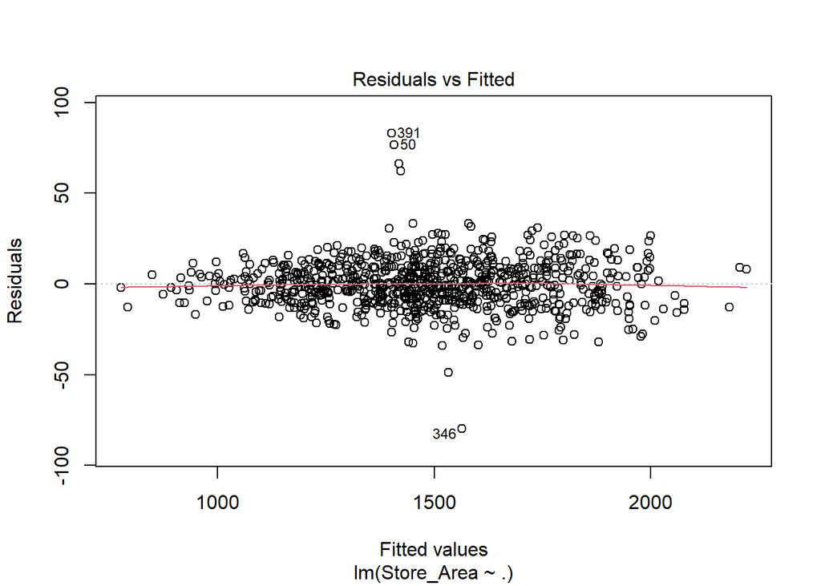

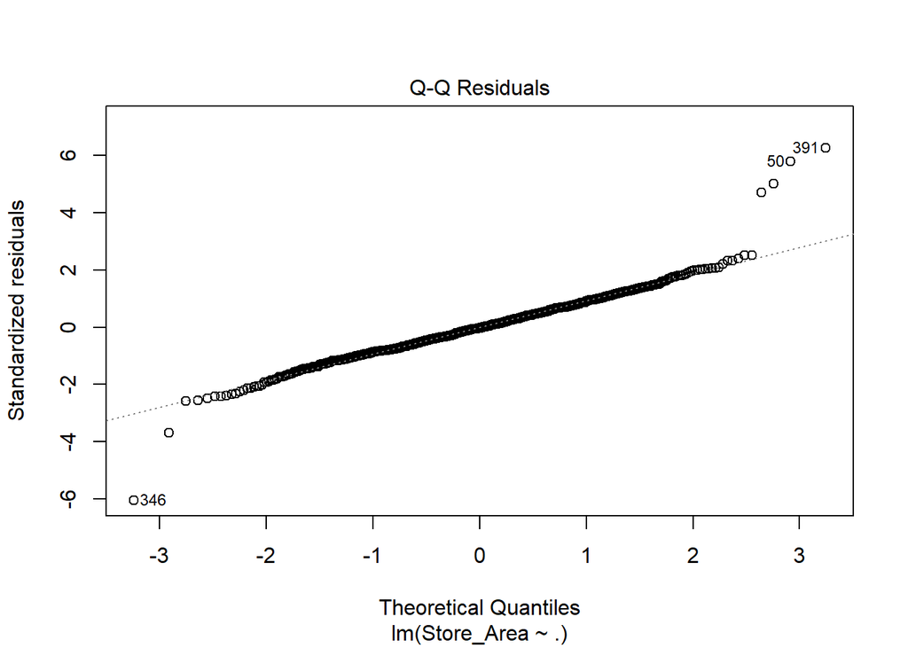

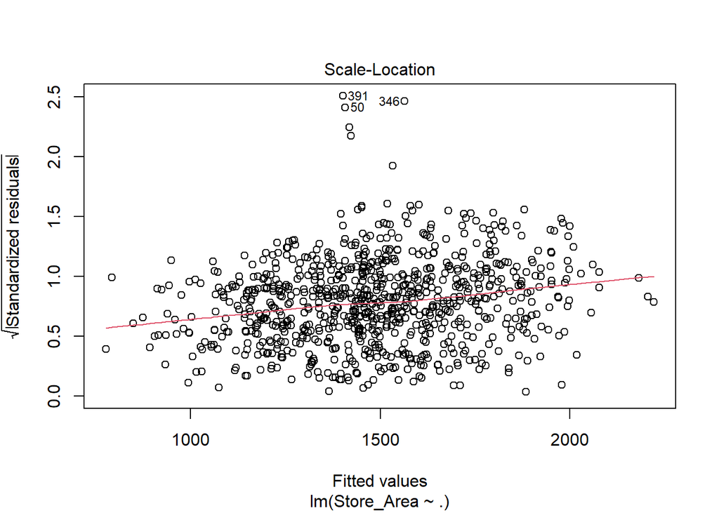

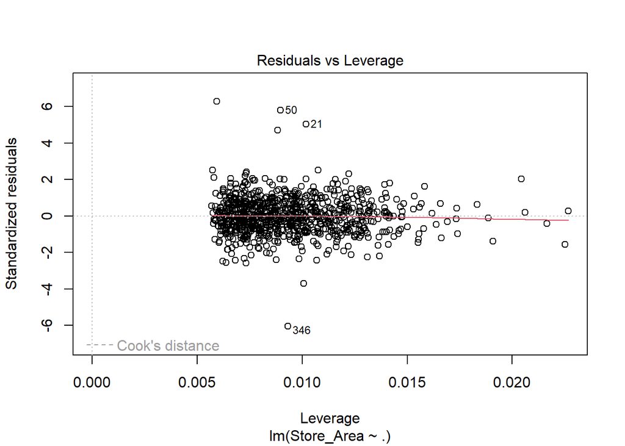

```
##
## Call:
## lm(formula = Store_Area ~ ., data = df_train[-bad_vector, ])
##
## Residuals:
##     Min      1Q  Median      3Q     Max
## -79.914  -8.478  -0.316   8.103  82.967
##
## Coefficients:
##                                   Estimate Std. Error t value Pr(>|t|)
## (Intercept)                      6.475e-01  3.526e+00   0.184    0.854
## Items_Available                  8.333e-01  1.523e-03 547.016   <2e-16 ***
## Daily_Customer_Count             9.781e-04  1.727e-03   0.566    0.571
## Store_Sales                     -3.012e-05  2.668e-05  -1.129    0.259
## Self_ServiceYes                 -7.911e-02  9.121e-01  -0.087    0.931
## Organisation_LevelInternational  2.056e+00  1.311e+00   1.568    0.117
## Organisation_LevelLocal          2.015e+00  1.276e+00   1.579    0.115
## Organisation_LevelRegional      -5.003e-02  1.278e+00  -0.039    0.969
## ---
## Signif. codes:  0 '***' 0.001 '**' 0.01 '*' 0.05 '.' 0.1 ' ' 1
##
## Residual standard error: 13.26 on 842 degrees of freedom
## Multiple R-squared:  0.9972, Adjusted R-squared:  0.9972
## F-statistic: 4.345e+04 on 7 and 842 DF,  p-value: < 2.2e-16
```

5. Распределение остатков

Поскольку выборка большая, будем использовать тест Колмогорова-Смирнова.

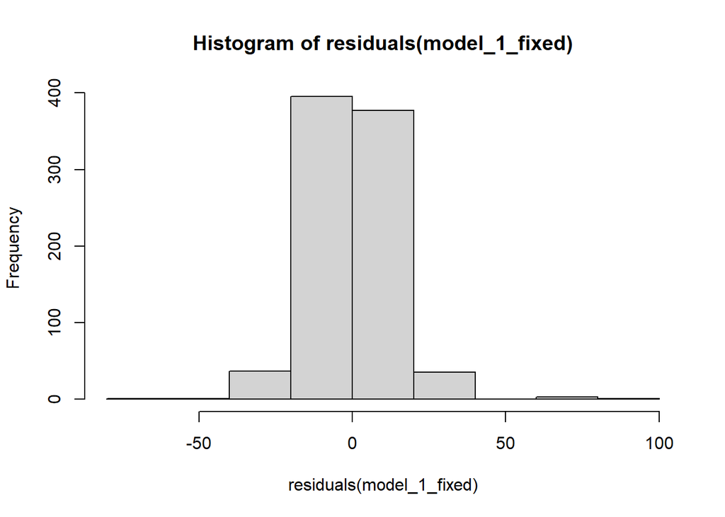

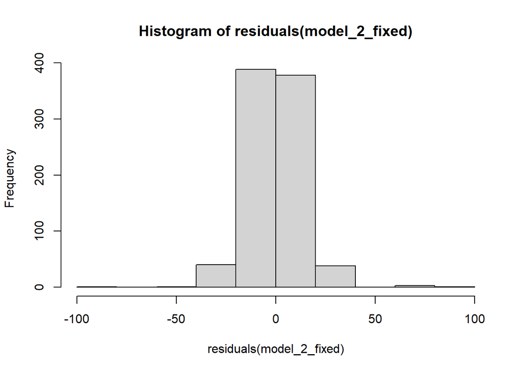

```
##
##  Asymptotic one-sample Kolmogorov-Smirnov test
##
## data:  residuals(model_1_fixed)
## D = 0.42031, p-value < 2.2e-16
## alternative hypothesis: two-sided
```

```
##
##  Asymptotic one-sample Kolmogorov-Smirnov test
##
## data:  residuals(model_2_fixed)
## D = 0.42193, p-value < 2.2e-16
## alternative hypothesis: two-sided
```

Распределение остатков не является нормальным.

## 4. Факторные переменные

Проверим с помощью стат. тестов, влияет ли принадлежность магазина к категориям (Organisation_Level и Self_Service) на другие показатели. Поскольку выборка большая (более 800 наблюдений), фактом отклонения распределения переменной Store_Sales можно пренебречь. Посмотрим, как влияют эти два фактора на остальные переменные с помощью дисперсионного анализа.

```
##                                  Df   Sum Sq Mean Sq F value Pr(>F)
## Organisation_Level                3   160637   53546   0.588  0.623
## Self_Service                      1    91464   91464   1.005  0.316
## Organisation_Level:Self_Service   3   193071   64357   0.707  0.548
## Residuals                       878 79896340   90998
```

```
##                                  Df    Sum Sq   Mean Sq F value Pr(>F)
## Organisation_Level                3 1.612e+09 537268814   1.818  0.142
## Self_Service                      1 1.992e+06   1991607   0.007  0.935
## Organisation_Level:Self_Service   3 1.602e+09 534020368   1.807  0.144
## Residuals                       878 2.595e+11 295527467
```

```
##                                  Df   Sum Sq Mean Sq F value Pr(>F)
## Organisation_Level                3   365408  121803   1.727  0.160
## Self_Service                      1    31166   31166   0.442  0.506
## Organisation_Level:Self_Service   3   226257   75419   1.069  0.361
## Residuals                       878 61941350   70548
```

```
##                                  Df   Sum Sq Mean Sq F value Pr(>F)
## Organisation_Level                3   121862   40621   0.653  0.581
## Self_Service                      1    79878   79878   1.284  0.257
## Organisation_Level:Self_Service   3   143299   47766   0.768  0.512
## Residuals                       878 54606310   62194
```

Обнаружилось, что оба фактора, а также их взаимодействие не влияют ни на одну из характеристик супермаркета.

## Выводы

*В ходе исследования выполнены следующие задачи*:

- был проведен исследовательский анализ данных (создание и обработка пропущенных значений, поиск выбросов методом “ящика с усами”, преобразование строковых данных в факторные);
- получены визуализации распределения переменных, проведены тесты на нормальность методом Шапиро-Уилка;
- показано, что категориальные переменные не влияют на другие показатели;
- исследованы линейные зависимости между переменными с помощью скаттероплотов и корреляционной матрицы. Отобрана зависимая переменная;
- построены две модели, выполнены предсказания значений зависимой переменной;
- выполнен сравнительный анализ эффективности двух моделей;
- проведена проверка выполнения предпосылок для построения уравнения линейной регрессии. Удалены выбросы и выполнен перерасчёт моделей. В результате удаления выбросов удалось увеличить процент объясненной диспрерсии.

Фактор, определяющий площадь супермаркета - ассортимент товаров. Между этими параметрами сильнейшая положительная корреляционная связь.